# Apostila de R para Economia

## 8.6 ARIMA

Modelos ARIMA providenciam outras aproximações para a previsão de séries temporais.

Enquanto os modelos de suavização exponencial baseavam - se na descrição de têndencia e sazonalidade dos dados, o modelo ARIMA se baseia na autocorrelação dos dados

### 8.6.1 Estacionariedade

Antes de começar a falar do ARIMA, precisamos saber o conceito de estacionariedade.

Uma série temporal é dita estacionária quando suas propriedades não variam no tempo.

Exemplificando fracamente, quando sua média e variancia são constantes em toda a série.

Isso não ocorre quando presenciamos tendências e/ou sazonalidade em uma série.

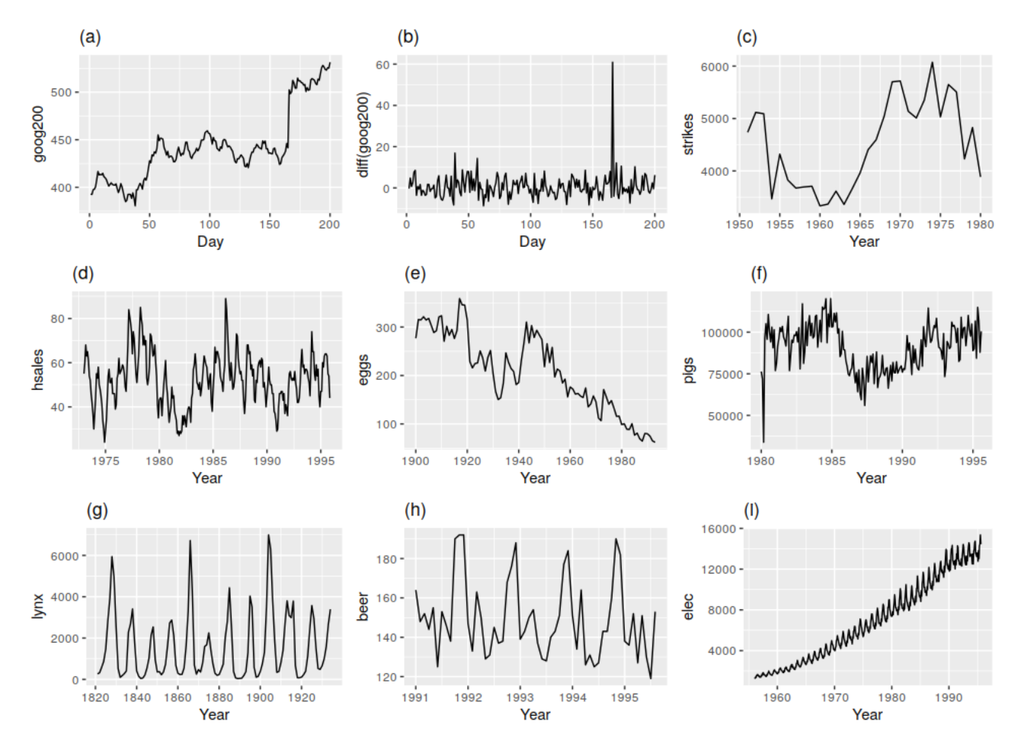

Estacionarias (B,G)

### 8.6.2 Diferenciação

Para lidar com o problema da Estacionariedade, podemos usar o conceito de **diferenciação**

Ela é calculada através da diferença entre os pontos consecutivos de uma série, estabilizando assim a média da mesma.

1° Diferença

$$y'_{t} = y_{t} - y_{t -1}$$
2° Diferença

$$y''_{t} = y'_{t} - y'_{t - 1}
= y_t - 2y_{t-1} +y_{t-2}$$
Diferença Sazonal

$$y'_t = y_t - y_{t-m}$$

### 8.6.3 Teste de estacionariedade

Há alguns testes que nos informam se uma série é estacionária. Os mais conhecidos são o ADF e o KPSS.

Nós iremos testar se a serie de passagens é estacionária com a função `ur.kpss` do pacote `urca`.

A hipótese nula é que a série é estacionária

```r
library(urca)

AirPassengers %>% ur.kpss() %>% summary()
```

```
##
## #######################
## # KPSS Unit Root Test #
## #######################
##
## Test is of type: mu with 4 lags.
##
## Value of test-statistic is: 2.7395
##
## Critical value for a significance level of:
##                 10pct  5pct 2.5pct  1pct
## critical values 0.347 0.463  0.574 0.739
```

O valor de test-statistic = 2.7395. O valor crítico há 1% é de 0.739

Ou seja, podemos rejeitar que ela é **estacionária**

Teremos então de diferenciar a série e testar novamente. Podemos diferenciar a série usando a função diff()

```r
AirPassengers %>% diff() %>% ur.kpss() %>% summary()
```

```
##
## #######################
## # KPSS Unit Root Test #
## #######################
##
## Test is of type: mu with 4 lags.
##
## Value of test-statistic is: 0.0146
##
## Critical value for a significance level of:
##                 10pct  5pct 2.5pct  1pct
## critical values 0.347 0.463  0.574 0.739
```

Como o valor de teste é menor do que o valor crítico a 1%, não rejeitamos que a 1° diferença é estacionária.

### 8.6.4 Modelos Autorregresivos

Modelos auto regressivos são parecidos com os modelos de regressão múltipla. Porém as variaveis exógenas agora são os valores defasados da variável endógena.

$$y_{t} = c + \phi_{1}y_{t-1} + \phi_{2}y_{t-2} + \dots + \phi_{p}y_{t-p} + \varepsilon_{t}$$
Nós nos referimos a esses modelos como um AR(p), onde p é a ordem da defasagem

### 8.6.5 Modelos de médias móveis

Em vez de usar valores passados da variável de previsão em uma regressão, um modelo de média móvel usa erros de previsão passados em um modelo semelhante a regressão.

$$y_{t} = c + \varepsilon_t + \theta_{1}\varepsilon_{t-1} + \theta_{2}\varepsilon_{t-2} + \dots + \theta_{q}\varepsilon_{t-q}$$
Nós nos referimos a isso como um MA (q), um modelo de média móvel de ordem q. Obviamente, não observamos os valores de $\varepsilon$, portanto, não é realmente uma regressão no sentido usual.

### 8.6.6 ARIMA Especificação

Se combinarmos diferenciação com autoregressão e um modelo de média móvel, obteremos um modelo ARIMA não sazonal. O modelo completo não sazonal pode ser escrito como

$$y'_{t} = c + \phi_{1}y'_{t-1} + \cdots + \phi_{p}y'_{t-p}
+ \theta_{1}\varepsilon_{t-1} + \cdots + \theta_{q}\varepsilon_{t-q} + \varepsilon_{t}$$

Nos chamamos esse modelo de ARIMA(p,d,q) onde

p = parte auto regressiva d = n° de diferenciações q = parte média movel

### 8.6.7 Estimando um ARIMA

Especificar um arima por conta prórpia requer prática, o que por enquanto está fora do escopo desse curso.

Porém, o R traz a possibilidade de você estimar o melhor modelo possivel com a função `auto.arima`

### 8.6.8 Gerando o modelo

```r
fit <- auto.arima(AirPassengers)
summary(fit)
```

```
## Series: AirPassengers
## ARIMA(2,1,1)(0,1,0)[12]
##
## Coefficients:
##          ar1     ar2      ma1
##       0.5960  0.2143  -0.9819
## s.e.  0.0888  0.0880   0.0292
##
## sigma^2 estimated as 132.3:  log likelihood=-504.92
## AIC=1017.85   AICc=1018.17   BIC=1029.35
##
## Training set error measures:
##                    ME     RMSE     MAE       MPE     MAPE     MASE         ACF1
## Training set 1.342299 10.84619 7.86754 0.4206976 2.800458 0.245628 -0.001248475
```

### 8.6.9 Gerando Previsão

```r
prev <- forecast(fit,12)
```

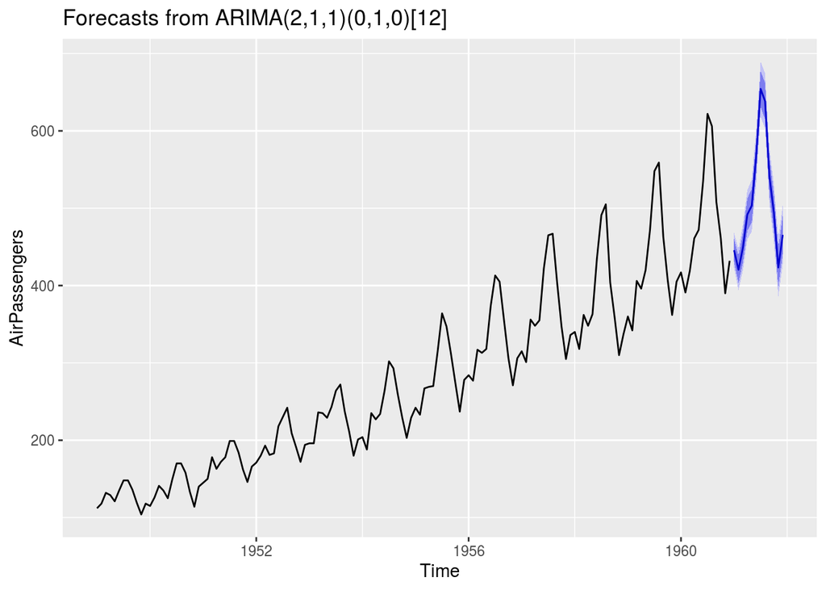

```r
autoplot(prev)
```